# PYTHON

After my master’s degree, due to my passion for programming lenguages, I decided to study independently Python and some of its modules:

- numpy
- Pandas
- Matplotlib/plotly
- Sql3lite
- Urllib
- Tkinter
- Tensor Flow

I also followed a brief online course on MySQL.

This has allowed me to improve in dealing with large amount of data and their visualization.

```python
df=pd.read_excel(r'C:\Users\983726\file maria\venti_perfetto.xlsx',sheet_name=0,header=0)
print(df.size,'numbers of Data')
```

```
245280 numbers of Data
```

```python
init_notebook_mode(connected=True)
iplot(px.line(df, x="Data_Ora_corretto", y="Vel.vento(m/s)"))
```

[interactive chart not shown]

[figure not shown]

# GIS

Throughout the *Telerilevamento* exam i had the opportunity to experience for the first time QGIS and remote sencing and, therefore, the various satellites, their orbit, spatial resolution, spectral resolution, temporal resolution, ecc. I've also learned the basic equations to convert a raster file in an information (ex. NDVI). I also have used Arcgis for a brief period during my internship.

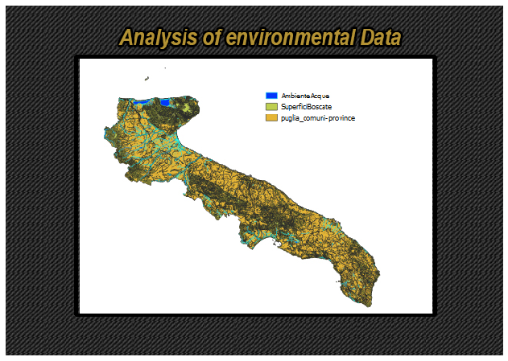

```python
plt.figure(figsize = (12,8))
plt.axis('off')
plt.imshow(mpimg.imread(r'C:\Users\983726\Documents\colloqui\planetek\gis_environmental.jpg'))
```

During my thesis, due to my work with unstructured and structured grids, I got the chance to train with software like *SMS (Surface water Madelling System)* and *Matlab*, so i could improve my skills in dealing with large matrices. I have also improved my QGIS knowledge with raster and vectors and I've acquired a lot of useful plugins.

```python
#<center>
#<img src="C:\Users\983726\Documents\colloqui\planetek\gis_raster_grid.jpg" width="600px" height="500px" align="center" />
#</center>
```

[figure not shown]

# MATLAB

I have experienced Matlab during my thesis and this led me to know better its lenguage and some of its functions. I have used it for the study of the hydrodynamic of Tricase harbour.

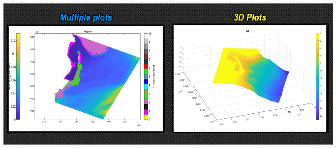

```python
plt.figure(figsize = (12,8))
plt.axis('off')
plt.imshow(mpimg.imread(r'C:\Users\983726\Documents\colloqui\planetek\Matlab.jpg'))
```

[figure not shown]

# SKILL

This is a word graph, created with d3 javascript, that summarizes my skills.

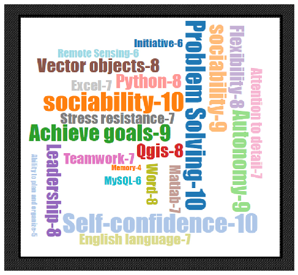

```python
plt.figure(figsize = (12,8))
plt.axis('off')
plt.imshow(mpimg.imread(r'C:\Users\983726\Documents\colloqui\planetek\skill.jpg'))
```